# FirstModelsPressuresPaco

En primer lugar se:

1. Leen los datos
2. Colocan en formato de tabla larga
3. Genera la columna de temperaturas
4. Factorizan las columnas necesarias para el modelado covariante
5. Seleccionan antocianos

Para empezar, generamos una gráfica de primer orden aparente para estudiar la importancia de la temperatura

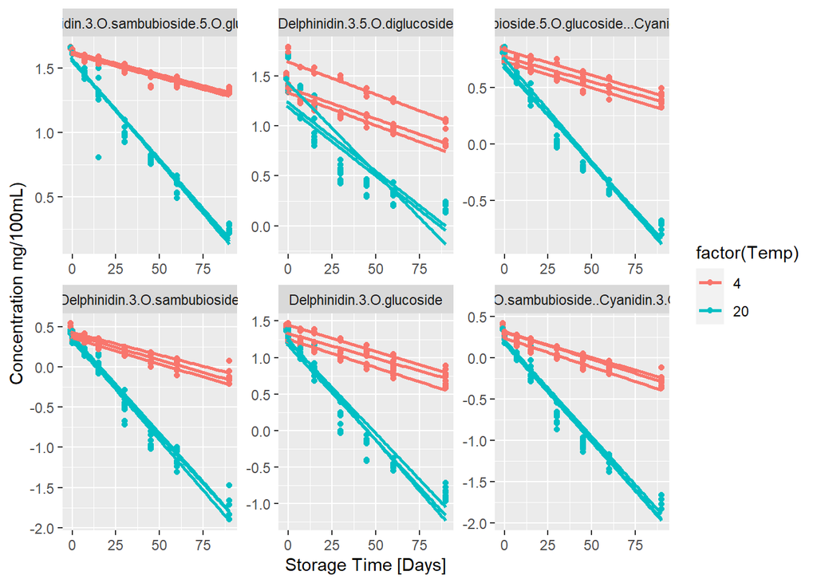

```r
ggplot(anthocyanins,
       aes(x = tiempo, y = log(concentration), group =sweetener:processing:factor(Temp),color=factor(Temp))) +
  facet_wrap(compound~.,scales="free")+
  geom_point()+ geom_smooth(method="lm",se = F)+
  xlab("Storage Time [Days]")+ylab("Concentration mg/100mL)")
```

De aquí podemos concluir que:

1. La temperatura de almacenamiento es el factor más importante del estudio. Las diferencias entre colores son mucho mayores que las diferencias entre líneas del mismo color
2. Todas las antocianos salvo Delphinidin.3.5.O.diglucoside podrían razonablemente ser modeladas con un cinética de primer orden aparentemente.

Procedemos a la primera modelización, una degradación de primer orden aparente con una concentración residual y una energía de activación, un modelo de referencia, con dependencia de la temperatura pero ni procesado ni endulzante afectan, con la siguiente distribución, derivada de la ecuación de Arrhenius y la cinética de primer orden:

$$C(t)_i \sim C_{\infty_i}+(C_{0_i}-C_{\infty_i})e^{(-e^{(lk_i-\frac{Ea_i}{R} \frac{1}{ T}-\frac{1}{T_{ref}})})t}$$
Donde $C(t)_i$ es la concentracion del antocianino i a tiempo t y $C_{0_i}$ $C_{\infty}$ $lk_i$ and $Ea_i$ son la concentracion inicial, concentracion final, el logaritmo natural de la constante aparente de primer orden y la energia de activacion para el antocianino i. La temperatura de referencia es $16^oC$ y la constante R es $0.008314 \frac{KJ}{Mol\cdot K}$.

```r
ant.fm0<-gnls(concentration~Cinf+(C0-Cinf)*exp(-exp(lk-Ea/8.314e-3*(1/(Temp+273)-1/(16+273)))*tiempo),
              data=anthocyanins,
              param=list(C0~compound,
                         Cinf~compound,
                         lk~compound,
                         Ea~compound),
              start=c(C0=c(1,rep(0.001,5)),
                      Cinf=c(0,rep(0.001,5)),
                      lk=c(0.01,rep(0.001,5)),
                      Ea=c(10,rep(0.001,5)))
)
summary(ant.fm0,cor=F)
```

[output not shown]

*Modelizacion de la co-varianza*

Con el diseño experimental se pueden estimar los efectos principales de las variables endulzante y procesado para compuesto. La estimacion de interacciones y los terminos de orden superior requeriria completar este diseño.

En este modelo endulzante y procesado son efectos iguales para todos los compuestos.

```r
ant.fm1<-gnls(concentration~Cinf+(C0-Cinf)*exp(-exp(lk-Ea/8.314e-3*(1/(Temp+273)-1/(16+273)))*tiempo),
              data=anthocyanins,
              param=list(C0~compound+sweetener+processing,
                         Cinf~compound+sweetener+processing,
                         lk~compound+sweetener+processing,
                         Ea~1),
              start=c(C0=c(coef(ant.fm0)[1:6],rep(0.001,3)),
                      Cinf=c(coef(ant.fm0)[7:12],rep(0.001,3)),
                      lk=c(coef(ant.fm0)[13:18],rep(0.001,3)),
                      Ea=c(coef(ant.fm0)[19])
                      )
)
summary(ant.fm1)
```

[output not shown]

Ahora intentaremos estimar los diferentes coeficientes de constantes entre diferentes componentes y condiciones de procesamiento

```r
ant.fm2<-gnls(concentration~Cinf+(C0-Cinf)*exp(-exp(lk-Ea/8.314e-3*(1/(Temp+273)-1/(16+273)))*tiempo),
               data=anthocyanins,
               param=list(C0~compound+sweetener+processing,
                          Cinf~compound+sweetener+processing,
                          lk~compound+sweetener+compound:processing,
                          Ea~compound),
               start=c(C0=c(coef(ant.fm0)[1:6],rep(0.001,3)),
                       Cinf=c(coef(ant.fm0)[7:12],rep(0.001,3)),
                       lk=c(coef(ant.fm0)[13:18],rep(0.001,13)),
                       Ea=c(coef(ant.fm0)[19],rep(0.001,5))
               )
)
summary(ant.fm2)
```

[output not shown]

Realizamos un análisis anova para los resultados de los modelos:

```r
anova(ant.fm0,ant.fm1,ant.fm2)
```

|  | call | Model | df | AIC | BIC | logLik | Test | L.Ratio | p-value |
| --- | --- | --- | --- | --- | --- | --- | --- | --- | --- |
| ant.fm0 | gnls(model = concentration ~ Cinf + (C0 - Cinf) * exp(-exp(lk - Ea/0.008314 * (1/(Temp + 273) - 1/(16 + 273))) * tiempo), data = anthocyanins, params = list(C0 ~ compound, Cinf ~ compound, lk ~ compou… | 1 | 25 | 71.25632 | 190.29564 | -10.62816 |  | NA | NA |
| ant.fm1 | gnls(model = concentration ~ Cinf + (C0 - Cinf) * exp(-exp(lk - Ea/0.008314 * (1/(Temp + 273) - 1/(16 + 273))) * tiempo), data = anthocyanins, params = list(C0 ~ compound + sweetener + processing, Cin… | 2 | 29 | -177.22100 | -39.13539 | 117.61050 | 1 vs 2 | 256.4773 | 2.618485e-54 |
| ant.fm2 | gnls(model = concentration ~ Cinf + (C0 - Cinf) * exp(-exp(lk - Ea/0.008314 * (1/(Temp + 273) - 1/(16 + 273))) * tiempo), data = anthocyanins, params = list(C0 ~ compound + sweetener + processing, Cin… | 3 | 44 | -291.24731 | -81.73811 | 189.62366 | 2 vs 3 | 144.0263 | 3.686164e-23 |

Las mejoras en los modelos son muy significativas y mejoran el ruido

Realizamos un cuarto modelo, con los coeficientes de los factores en todas las variables

```r
ant.fm3<-gnls(concentration~Cinf+(C0-Cinf)*exp(-exp(lk-Ea/8.314e-3*(1/(Temp+273)-1/(16+273)))*tiempo),
               data=anthocyanins,
               param=list(C0~compound+compound:sweetener+compound:processing,
                          Cinf~compound+compound:sweetener+compound:processing,
                          lk~compound+compound:sweetener+compound:processing,
                          Ea~compound),
               start=c(C0=c(coef(ant.fm0)[1:6],rep(0.001,18)),
                       Cinf=c(coef(ant.fm0)[7:12],rep(0.001,18)),
                       lk=c(coef(ant.fm0)[13:18],rep(0.001,18)),
                       Ea=c(coef(ant.fm0)[13:18])
               )
)
screenreg(ant.fm3,single.row=T,ci.force=T)
```

[output not shown]

De nuevo, evaluamos los modelos con anova, y miramos el r2 del cuarto modelo

```r
anova(ant.fm0,ant.fm1,ant.fm2,ant.fm3)
```

|  | call | Model | df | AIC | BIC | logLik | Test | L.Ratio | p-value |
| --- | --- | --- | --- | --- | --- | --- | --- | --- | --- |
| ant.fm0 | gnls(model = concentration ~ Cinf + (C0 - Cinf) * exp(-exp(lk - Ea/0.008314 * (1/(Temp + 273) - 1/(16 + 273))) * tiempo), data = anthocyanins, params = list(C0 ~ compound, Cinf ~ compound, lk ~ compou… | 1 | 25 | 71.25632 | 190.29564 | -10.62816 |  | NA | NA |
| ant.fm1 | gnls(model = concentration ~ Cinf + (C0 - Cinf) * exp(-exp(lk - Ea/0.008314 * (1/(Temp + 273) - 1/(16 + 273))) * tiempo), data = anthocyanins, params = list(C0 ~ compound + sweetener + processing, Cin… | 2 | 29 | -177.22100 | -39.13539 | 117.61050 | 1 vs 2 | 256.4773 | 2.618485e-54 |
| ant.fm2 | gnls(model = concentration ~ Cinf + (C0 - Cinf) * exp(-exp(lk - Ea/0.008314 * (1/(Temp + 273) - 1/(16 + 273))) * tiempo), data = anthocyanins, params = list(C0 ~ compound + sweetener + processing, Cin… | 3 | 44 | -291.24731 | -81.73811 | 189.62366 | 2 vs 3 | 144.0263 | 3.686164e-23 |
| ant.fm3 | gnls(model = concentration ~ Cinf + (C0 - Cinf) * exp(-exp(lk - Ea/0.008314 * (1/(Temp + 273) - 1/(16 + 273))) * tiempo), data = anthocyanins, params = list(C0 ~ compound + compound:sweetener + compou… | 4 | 79 | -625.57663 | -249.41238 | 391.78832 | 3 vs 4 | 404.3293 | 2.234909e-64 |

```r
r2(ant.fm3)
```

```
## [1] 0.9886055 0.9874892
```

Realizamos gráficas de diagnóstico para el cuarto modelo

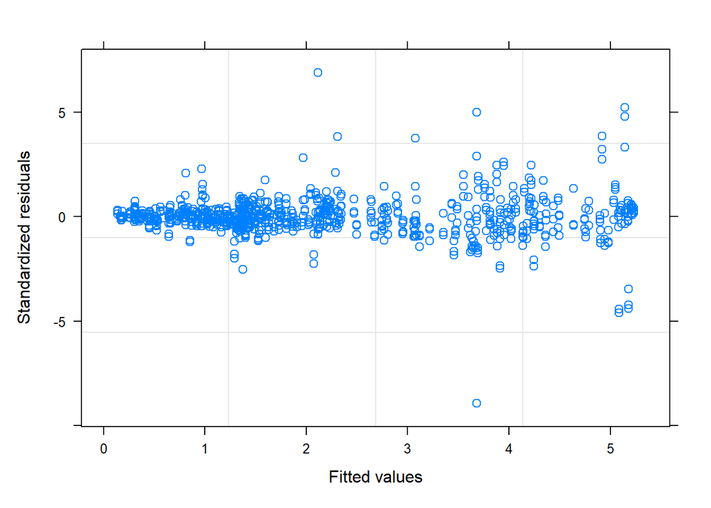

```r
plot(ant.fm3)
```

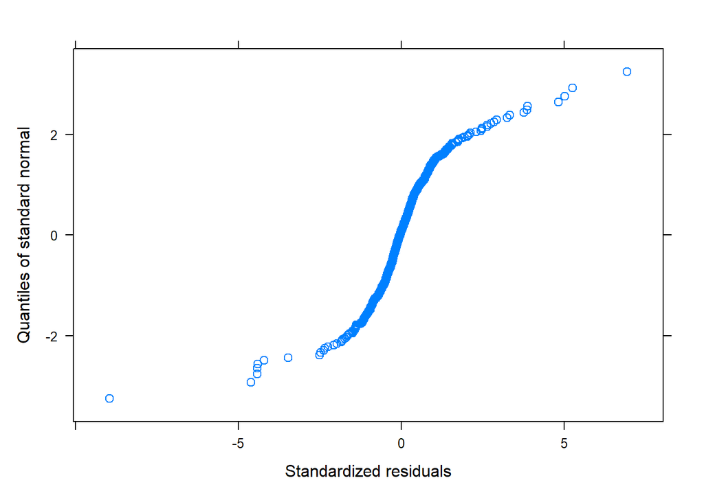

```r
qqnorm(ant.fm3)
```

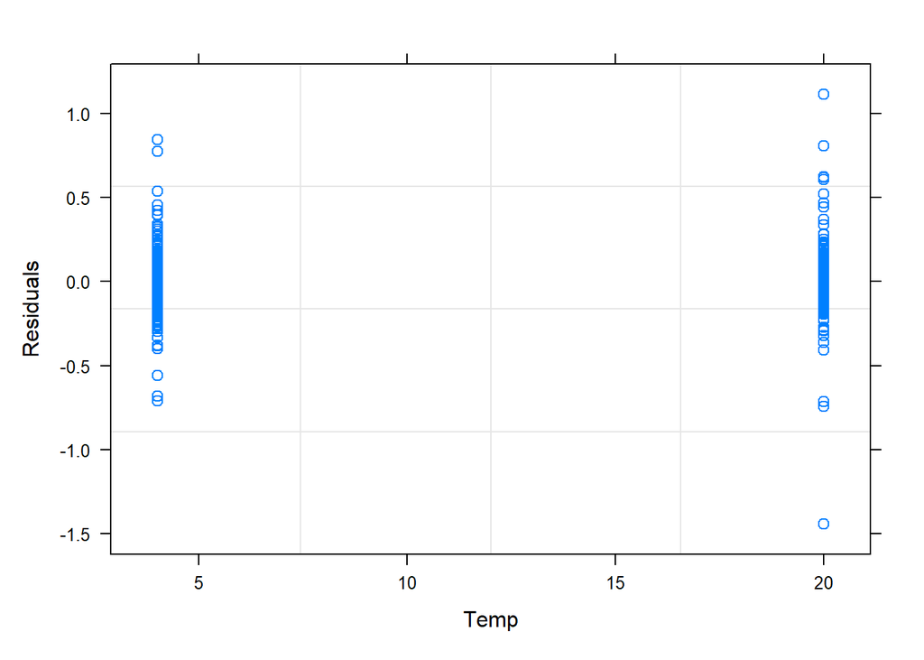

```r
plot(ant.fm3,resid(.)~Temp)
```

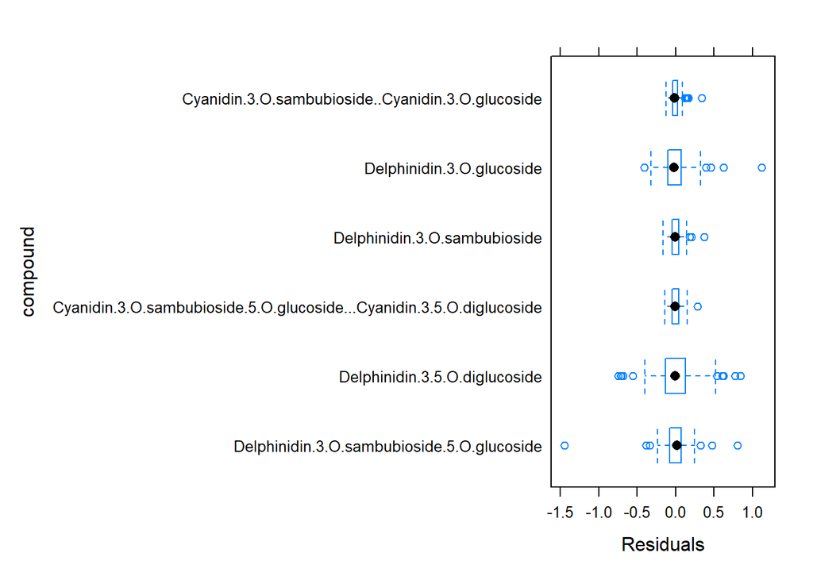

```r
plot(ant.fm3,compound~resid(.))
```

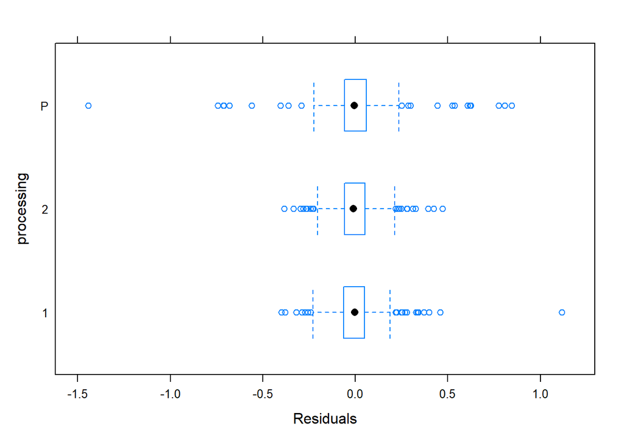

```r
plot(ant.fm3,processing~resid(.))
```

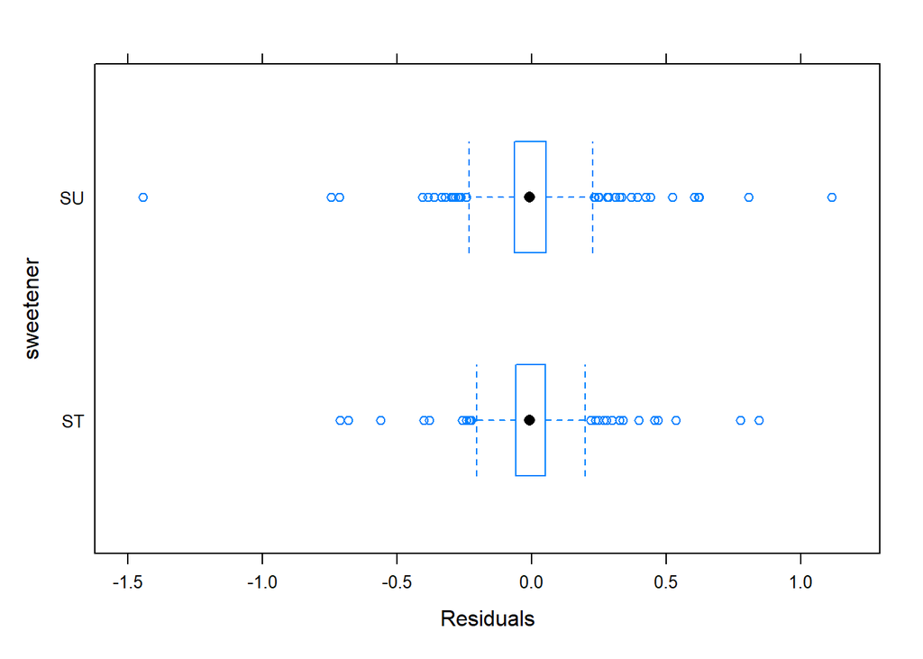

```r
plot(ant.fm3,sweetener~resid(.))
```

```r
list.of.compound.fit<-list()
list.of.r2adj<-list()
for (i in levels(factor(anthocyanins$compound))){
  #print(i)
  list.of.compound.fit[[i]]<-gnls(concentration~Cinf+(C0-Cinf)*exp(-exp(lk-Ea/8.314e-3*(1/(Temp+273)-1/(16+273)))*tiempo),
                                  data=subset(anthocyanins,compound==i),
                                  param=list(C0~sweetener+processing,
                                             Cinf~sweetener+processing,
                                             lk~sweetener+processing,
                                             Ea~1),
                                  start=c(C0=c(5.05,rep(0.001,3)),
                                          Cinf=c(0,rep(0.001,3)),
                                          lk=c(-4.38,rep(0.001,3)),
                                          Ea=c(67)
                                  )
  )
  list.of.r2adj[[i]]<-round(r2(list.of.compound.fit[[i]])[2],3)
}

#screenreg(list.of.compound.fit,single.row=T,ci.force=T)
```

[output not shown]

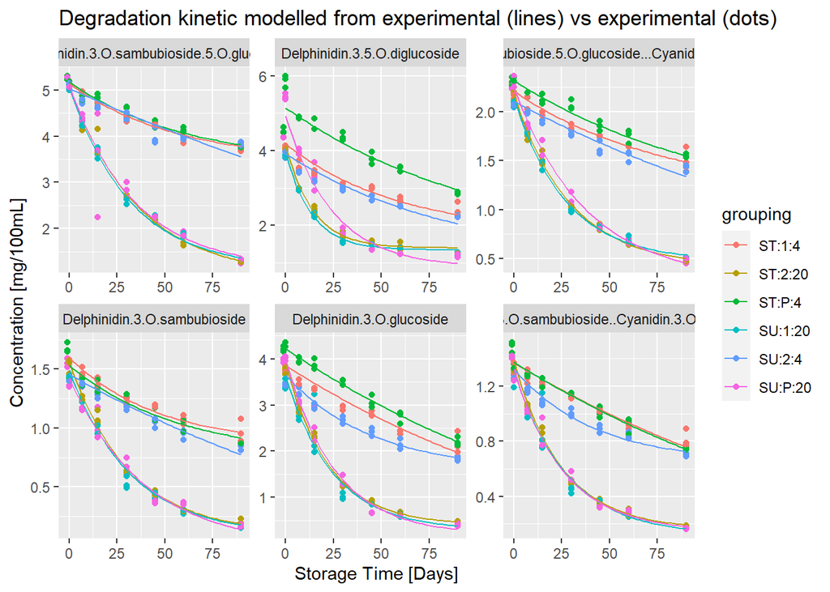

```r
anthocyanins$grouping<-factor(with(anthocyanins,sweetener:processing:factor(Temp)))

ant.pred<-expand.grid(tiempo=seq(0,90,length=50),
                       compound=levels(factor(anthocyanins$compound)),
                       grouping=levels(factor(anthocyanins$grouping))
                       )
ant.pred$sweetener<-factor(with(ant.pred,substr(grouping,0,2)))
ant.pred$processing<-factor(with(ant.pred,substr(grouping,4,4)))
ant.pred$Temp<-as.numeric(with(ant.pred,substr(grouping,6,8)))
ant.pred$concentration<-predict(ant.fm3,newdata = ant.pred)
ggplot(anthocyanins,
       aes(x = tiempo, y = concentration, col =grouping)) +
  facet_wrap(compound~.,scales="free")+
  geom_point()+geom_line(data=ant.pred,aes(x=tiempo,y=concentration,col=grouping))+
  ggtitle("Degradation kinetic modelled from experimental (lines) vs experimental (dots)")+
  xlab("Storage Time [Days]")+ylab("Concentration [mg/100mL]")
```

```r
ggsave(filename="Figure1.pdf")
```

Podemos concluir que este cuarto modelo ajusta bastante bien la degradación del compuesto respecto a los datos experimentales salvo algún punto marginal, y que puede emplearse para realizar predicciones bastante ajustadas en el caso de los antocianos.

Por tanto, generamos una grilla de datos para simular las condiciones en las que carecemos de información, realizamos la predicción y representamos cada condición a todos los compuestos:

```r
ant.simul2<-expand.grid(tiempo=seq(0,90,length=30),
                        Temp = c(4,20),
                        compound=levels(factor(anthocyanins$compound)),

grouping=c("ST:1", "ST:2", "ST:P","SU:1", "SU:2", "SU:P"))
ant.simul2$grouping <- factor(ant.simul2$grouping:factor(ant.simul2$Temp))
ant.simul2$sweetener<-factor(with(ant.simul2,substr(grouping,0,2)))
ant.simul2$processing<-factor(with(ant.simul2,substr(grouping,4,4)))
ant.simul2$prediction<-predict(ant.fm3,newdata = ant.simul2)

# añadimos confidence bands

fm3.dm <- predict_gnls(ant.fm3, newdata = ant.simul2, interval = "conf")
ant.simul2.dm <- cbind(ant.simul2, fm3.dm)

# ggplot(ant.simul2,
#        aes(x = tiempo, y = prediction, col = factor(Temp))) +
#   facet_grid(processing+sweetener~factor(compound),scales="free")+
#   geom_point()+geom_line()+
#   xlab("Storage Time [Days]")+ylab("Concentration [mg/100mL]")
```

Ahora procedemos a representar cada una de las condiciones separando las temperaturas, para comparar los datos experimentales con los simulados

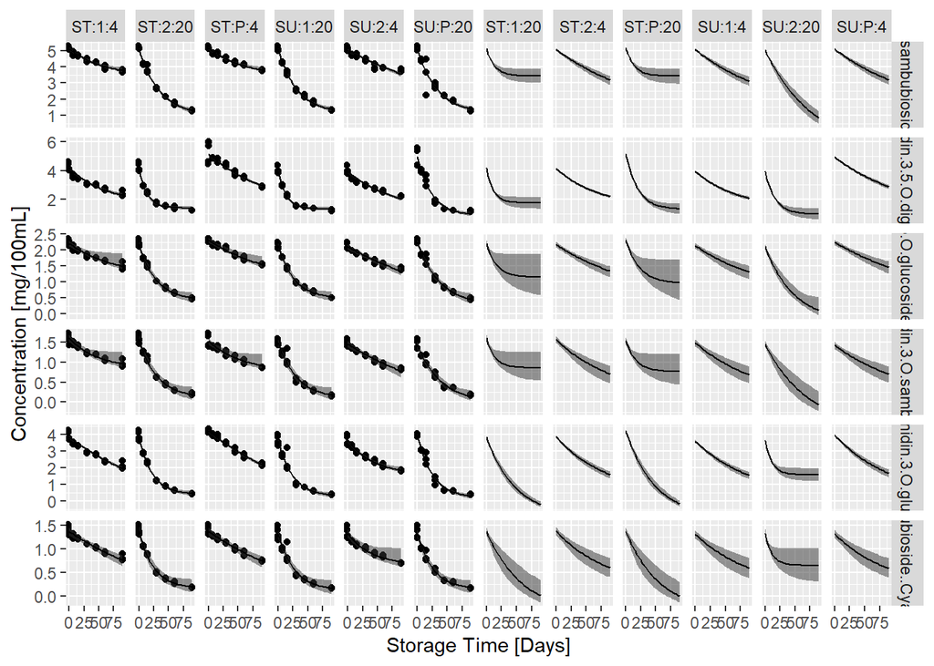

```r
# ST:1
ggplot(data = anthocyanins, aes(x=tiempo, y = concentration))+
  facet_grid(compound~factor(grouping),scales="free")+
  geom_point()+
  geom_ribbon(data=ant.simul2.dm,aes(y = prediction, ymin= Q2.5, ymax = Q97.5), alpha=0.5)+
  geom_line(data=ant.simul2,aes(y=prediction))+
  xlab("Storage Time [Days]")+ylab("Concentration [mg/100mL]")
```

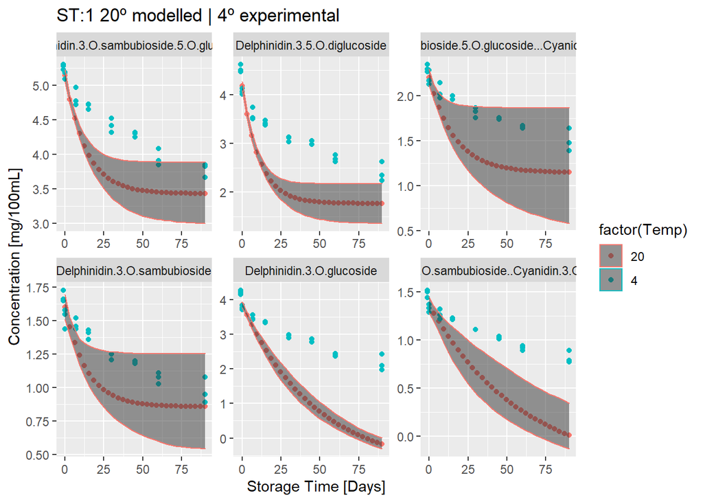

```r
ggplot(data = subset(ant.simul2.dm,grouping == "ST:1:20"), aes(x=tiempo, y = prediction, col = factor(Temp)))+
  facet_wrap(compound~.,scales="free")+
  geom_point()+
  geom_point(data=subset(anthocyanins,grouping == "ST:1:4"), aes(x=tiempo, y=concentration, col = factor(Temp)))+
  geom_ribbon(aes(x = tiempo, ymin= Q2.5, ymax = Q97.5), alpha=0.5)+
  ggtitle("ST:1 20º modelled | 4º experimental") + xlab("Storage Time [Days]")+ylab("Concentration [mg/100mL]")
```

[figure not shown]

```r
# ST:2
ggplot(data = ant.simul2.dm %>% filter(grouping == "ST:2:4"), aes(x=tiempo, y = prediction, col = factor(Temp)))+
  facet_wrap(compound~.,scales="free")+
  geom_point()+
  geom_point(data=anthocyanins %>% filter(grouping == "ST:2:20"), aes(x=tiempo, y=concentration, col = factor(Temp)))+
  geom_ribbon(aes(x = tiempo, ymin= Q2.5, ymax = Q97.5), alpha=0.5)+
  ggtitle("SU:1 20º experimental | 4º modelled")+ xlab("Storage Time [Days]")+ylab("Concentration [mg/100mL]")
```

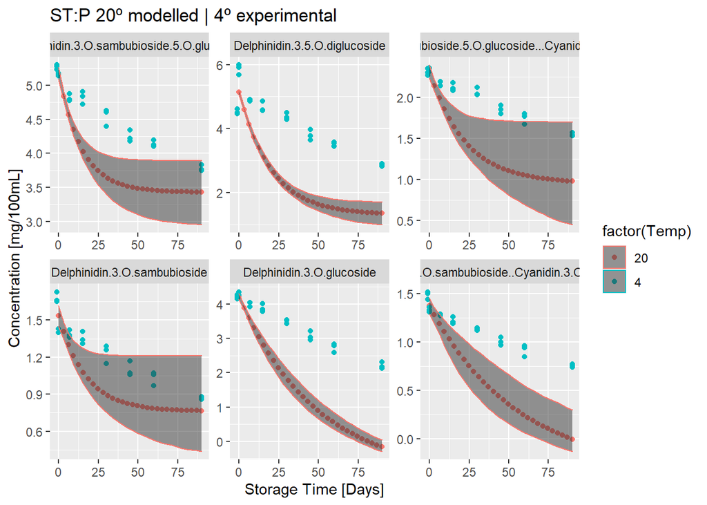

```r
# ST:P
ggplot(data = ant.simul2.dm %>% filter(grouping == "ST:P:20"), aes(x=tiempo, y = prediction, col = factor(Temp)))+
  facet_wrap(compound~.,scales="free")+
  geom_point()+geom_point(data=anthocyanins %>% filter(grouping == "ST:P:4"), aes(x=tiempo, y=concentration, col = factor(Temp)))+
  geom_ribbon(aes(x = tiempo, ymin= Q2.5, ymax = Q97.5), alpha=0.5)+
  ggtitle("ST:P 20º modelled | 4º experimental")+ xlab("Storage Time [Days]")+ylab("Concentration [mg/100mL]")
```

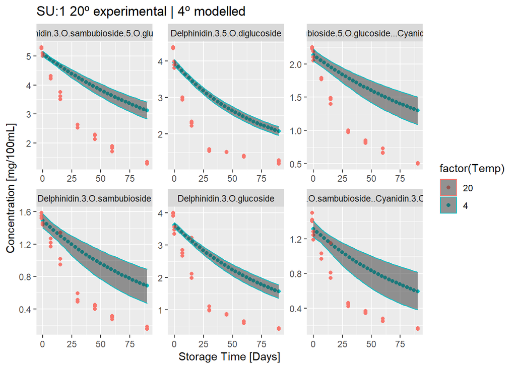

```r
# SU:1

ggplot(data = ant.simul2.dm %>% filter(grouping == "SU:1:4"), aes(x=tiempo, y = prediction, col = factor(Temp)))+
  facet_wrap(compound~.,scales="free")+
  geom_point()+
  geom_point(data=anthocyanins %>% filter(grouping == "SU:1:20"), aes(x=tiempo, y=concentration, col = factor(Temp))) +
  geom_ribbon(aes(x = tiempo, ymin= Q2.5, ymax = Q97.5), alpha=0.5)+
  ggtitle("SU:1 20º experimental | 4º modelled")+ xlab("Storage Time [Days]")+ylab("Concentration [mg/100mL]")
```

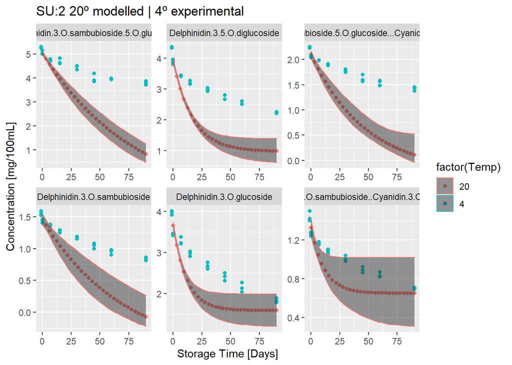

```r
# SU:2

ggplot(data = ant.simul2.dm %>% filter(grouping == "SU:2:20"), aes(x=tiempo, y =prediction, col = factor(Temp)))+
  facet_wrap(compound~.,scales="free")+
  geom_point()+
  geom_point(data=anthocyanins %>% filter(grouping == "SU:2:4"), aes(x=tiempo, y=concentration, col = factor(Temp))) +
  geom_ribbon(aes(x = tiempo, ymin= Q2.5, ymax = Q97.5), alpha=0.5)+
  ggtitle("SU:2 20º modelled | 4º experimental")+ xlab("Storage Time [Days]")+ylab("Concentration [mg/100mL]")
```

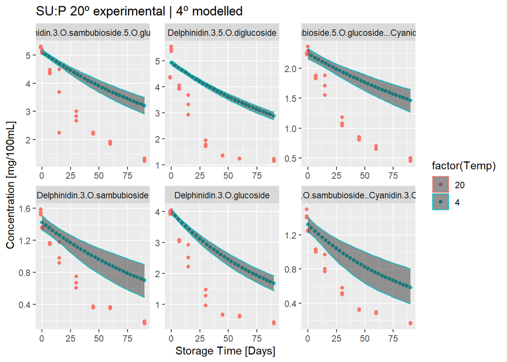

```r
# SU:P

ggplot(data = ant.simul2.dm %>% filter(grouping == "SU:P:4"), aes(x=tiempo, y = prediction, col = factor(Temp)))+
  facet_wrap(compound~.,scales="free")+
  geom_point()+
  geom_point(data=anthocyanins %>% filter(grouping == "SU:P:20"), aes(x=tiempo, y=concentration, col = factor(Temp))) +
  geom_ribbon(aes(x = tiempo, ymin= Q2.5, ymax = Q97.5), alpha=0.5)+
  ggtitle("SU:P 20º experimental | 4º modelled")+ xlab("Storage Time [Days]")+ylab("Concentration [mg/100mL]")
```